# Final assignment

Annika Lehmus-Sun, annika.lehmus@helsinki.fi

February, 26, 2017

# THE DATA

The data for the analysis is from the British Household Panel Survey (BHPS), more precisely its 10th wave that was collected in the year 2000. BHPS is an annual survey of each adult (16+) member of a nationally representative sample of more than 5000 households, comprising a total of approxi- mately 10 000 individual interviews.data from the 10th wave of interviews carried out in the year 2000.more information about the data: [British household panel survey wave 10](https://www.iser.essex.ac.uk/bhps/documentation/pdf_versions/index.html).

The data wrangling done for the analysis can be found from here: [The data wrangling for final assignment](https://github.com/AnnikaLehmusSun/IODS-final/blob/master/data/BHPS_create%20.R)

# THE RESEARCH QUESTION

The aim of this assignment is to study a correlation between objective well-being factors and subjective well-being. The objective well-being factors are based on the knowledge of Amartya Sen’s well-known capability approach. The notion of the capability approach is to stress that also the chances, not only outcomes matters in context of one’s subjective well-being. The indicator of subjective well-being is in this assignment one’s overall life satisfaction. The indicators of objective well-being are: capability to move away from one’s neigbourhood (JLKMOVE), quality of neigbourhood (JHSPRBQ), annual holiday (JHSCANB), cabability for annual holiday (JHSCNTB), new clothes (JHSCAND), capability to buy new clothes (JHSCNTD), contacts with family or friends (JHSCANF). The research question is: “How well do objective well-being factors correlate with subjective well-being?”

Below I have presented some overview and information of the dataframe and the variables:

```r
if (!require("pacman")) install.packages("pacman")
```

```r
pacman::p_load(haven, ggplot2,knitr, pander,descr,foreign,dplyr,Hmisc,psych,GPArotation,plyr, dplyr, rmarkdown)
BHPS2 <- read.csv(file = "/Applications/IODS-final/data/BHPS2.csv", sep=",")
BHPS2$X <- NULL
```

The data contains 15 603 observation and eight variables that are mentioned earlier.

```r
dim(BHPS2)
```

```
## [1] 15603     8
```

```r
describe(BHPS2)
```

```
##         vars     n  mean   sd median trimmed  mad min max range  skew
## JLKMOVE    1 15603  1.03 1.58      1    1.27 0.00  -7   2     9 -4.31
## JHSPRBQ    2 15603  1.66 1.23      2    1.87 0.00  -9   2    11 -6.55
## JHSCANB    3 15603  1.13 1.19      1    1.21 0.00  -9   2    11 -6.00
## JHSCNTB    4 15603 -5.49 4.15     -8   -6.11 0.00  -9   2    11  1.06
## JHSCAND    5 15603  0.93 1.11      1    1.00 0.00  -9   2    11 -6.91
## JHSCNTD    6 15603 -7.32 2.43     -8   -8.00 0.00  -9   2    11  3.34
## JHSCANF    7 15603  1.11 1.18      1    1.19 0.00  -9   2    11 -6.03
## JLFSATO    8 15603  4.40 3.33      5    5.12 1.48  -9   7    16 -2.93
##         kurtosis   se
## JLKMOVE    19.15 0.01
## JHSPRBQ    45.70 0.01
## JHSCANB    41.65 0.01
## JHSCNTB    -0.84 0.03
## JHSCAND    50.16 0.01
## JHSCNTD     9.24 0.02
## JHSCANF    41.89 0.01
## JLFSATO     8.33 0.03
```

The code and name of the variables used in the data-analysis

```r
variables <- matrix(c("QUESTION ASKED","If you could choose, would you stay here in your present home or would you prefer to move somewhere else?","Does your accommodation have any of the following problems? Vandalism or crime in the area", "Tell me which things you (and your household) have or do? Pay for a week’s annual holiday away from home.","Would you like to be able to pay for a week’s annual holiday away from home, but must do without because you cannot afford it?", "Tell me which things you (and your household) have or do? Buy new, rather than second hand, clothes.","Would you like to be able to buy new, rather than second hand, clothes, but must do without because you cannot afford it?","Tell me which things you (and your household) have or do? Have friends or family for a drink or meal at least once a month","How dissatisfied or satisfied are you with your life overall?"), ncol = 1, byrow =TRUE)
colnames(variables) <- c("BHPS 2000")
rownames(variables) <- c("VARIABLE NAME", "JLKMOVE", "JHSPRBQ","JHSCANB" , "JHSCNTB","JHSCAND", "JHSCNTD", "JHSCANF", "JLFSATO" )
variables <- as.table(variables)
variables
```

```
##               BHPS 2000
## VARIABLE NAME QUESTION ASKED
## JLKMOVE       If you could choose, would you stay here in your present home or would you prefer to move somewhere else?
## JHSPRBQ       Does your accommodation have any of the following problems? Vandalism or crime in the area
## JHSCANB       Tell me which things you (and your household) have or do? Pay for a week’s annual holiday away from home.
## JHSCNTB       Would you like to be able to pay for a week’s annual holiday away from home, but must do without because you cannot afford it?
## JHSCAND       Tell me which things you (and your household) have or do? Buy new, rather than second hand, clothes.
## JHSCNTD       Would you like to be able to buy new, rather than second hand, clothes, but must do without because you cannot afford it?
## JHSCANF       Tell me which things you (and your household) have or do? Have friends or family for a drink or meal at least once a month
## JLFSATO       How dissatisfied or satisfied are you with your life overall?
```

THE summaries of the variables:

```r
summary(BHPS2, digits = 2)
```

```
##     JLKMOVE      JHSPRBQ        JHSCANB        JHSCNTB        JHSCAND
##  Min.   :-7   Min.   :-9.0   Min.   :-9.0   Min.   :-9.0   Min.   :-9.00
##  1st Qu.: 1   1st Qu.: 2.0   1st Qu.: 1.0   1st Qu.:-8.0   1st Qu.: 1.00
##  Median : 1   Median : 2.0   Median : 1.0   Median :-8.0   Median : 1.00
##  Mean   : 1   Mean   : 1.7   Mean   : 1.1   Mean   :-5.5   Mean   : 0.93
##  3rd Qu.: 2   3rd Qu.: 2.0   3rd Qu.: 2.0   3rd Qu.: 1.0   3rd Qu.: 1.00
##  Max.   : 2   Max.   : 2.0   Max.   : 2.0   Max.   : 2.0   Max.   : 2.00
##     JHSCNTD        JHSCANF        JLFSATO
##  Min.   :-9.0   Min.   :-9.0   Min.   :-9.0
##  1st Qu.:-8.0   1st Qu.: 1.0   1st Qu.: 4.0
##  Median :-8.0   Median : 1.0   Median : 5.0
##  Mean   :-7.3   Mean   : 1.1   Mean   : 4.4
##  3rd Qu.:-8.0   3rd Qu.: 2.0   3rd Qu.: 6.0
##  Max.   : 2.0   Max.   : 2.0   Max.   : 7.0
```

The graphical overview of the data:

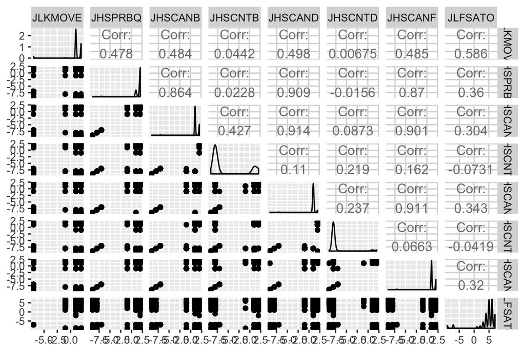

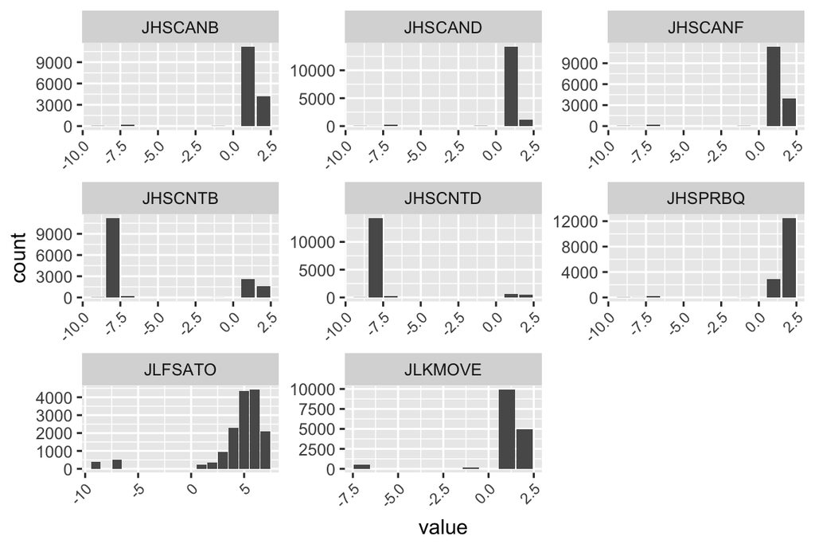

About the graphical overview. The first graph above gives hints of correlations between variables. According to the graph, it seems that there are rather little correlations between the capabilities (i.e. capability to buy new clothes and holidays away from home) and life satisfaction. I will investigate more closely about the correlation between objective well-being factors and subjective well-being in regression analysis.

# THE METHOD: LINEAR REGRESSION ANALYSIS

Regression analysis is probably one of the most used method for predicting correlations between variables - to understand how certain independent variables (in my model that is objective well-being factors) are related to the dependent variable (that is in this context one’s life satisfaction). The regression analysis helps to investigate different dimensions of the relationship and correlations. However, it is good to keep in mind that correlation does not (always) mean causality. (Armstrong, 2012.) The model1 (below) shows the correlations of the all independent variables and dependent variable.

## MODEL 1

The first linear regression model is done with all the variables. According to the model1 not all of the variables have significant correlation with the dependent variable.

```
##
## Call:
## lm(formula = JLFSATO ~ JLKMOVE + JHSPRBQ + JHSCANB + JHSCNTB +
##     JHSCAND + JHSCANF + JHSCNTD, data = BHPS2)
##
## Residuals:
##     Min      1Q  Median      3Q     Max
## -14.885  -0.734   0.266   1.266   7.186
##
## Coefficients:
##             Estimate Std. Error t value Pr(>|t|)
## (Intercept)  2.11475    0.08104  26.097  < 2e-16 ***
## JLKMOVE      1.15078    0.01572  73.188  < 2e-16 ***
## JHSPRBQ      0.39901    0.05330   7.486 7.51e-14 ***
## JHSCANB     -0.12999    0.15744  -0.826  0.40901
## JHSCNTB     -0.05414    0.01739  -3.112  0.00186 **
## JHSCAND      0.20779    0.14297   1.453  0.14615
## JHSCANF     -0.23019    0.05057  -4.551 5.37e-06 ***
## JHSCNTD     -0.04872    0.01754  -2.778  0.00548 **
## ---
## Signif. codes:  0 '***' 0.001 '**' 0.01 '*' 0.05 '.' 0.1 ' ' 1
##
## Residual standard error: 2.661 on 15595 degrees of freedom
## Multiple R-squared:  0.3636, Adjusted R-squared:  0.3633
## F-statistic:  1273 on 7 and 15595 DF,  p-value: < 2.2e-16
```

## THE P-VALUE

Interesting enough, only five variables seems to have significant correlation with life satisfaction. The other two variables, i.e. annual holidays and new clothes, had any statisctical signifancy with the respondent’s life satisfaction. Thus, since there is no statistical significanse between annual holidays nor purchase of new clothes, I will remove those two variables, and create a Model 2, with the remaining significant factors as the dependent variables. Although should we ignore the variables that does not have statistical significance, perhaps not. In the articel “Statistical errors. P values, ‘the gold standard’ of statistical validity, are not as reliable as many scientist assume”, Regina Nuzzo summarizes how nowadays P value of 0.01 means for a lot of scientists that there is just a 1% of chance that the result is being a false. However, p value does not tell that. All what P value is doing, is summarizing the data by assuming a spexifix null hypothesis (=that there is no correaltion between these variables, but our world does not work like that, usually variables do correlate). (Nuzzo, 2014.)

P value tells us yet something about existing correlation. Therefore, let’s take a closer look at regression model “model2”, where the ability to move, quality of neighbourhood, ability to afford annual holiday and new clothes, and connects with friends and family. are the independent variables (since there were the only ones with the statistical significance) and life satisfaction as the dependent variable:

## MODEL 2

```r
Model2 <- lm(JLFSATO~JLKMOVE+JHSPRBQ+JHSCNTB+JHSCANF+JHSCNTD, data = BHPS2)
summary(Model2)
```

```
##
## Call:
## lm(formula = JLFSATO ~ JLKMOVE + JHSPRBQ + JHSCNTB + JHSCANF +
##     JHSCNTD, data = BHPS2)
##
## Residuals:
##      Min       1Q   Median       3Q      Max
## -14.8855  -0.7326   0.2674   1.2674   7.1414
##
## Coefficients:
##              Estimate Std. Error t value Pr(>|t|)
## (Intercept)  2.142501   0.074652  28.700  < 2e-16 ***
## JLKMOVE      1.152858   0.015510  74.331  < 2e-16 ***
## JHSPRBQ      0.436342   0.036659  11.903  < 2e-16 ***
## JHSCNTB     -0.068371   0.005455 -12.533  < 2e-16 ***
## JHSCANF     -0.199464   0.038861  -5.133 2.89e-07 ***
## JHSCNTD     -0.027131   0.009020  -3.008  0.00263 **
## ---
## Signif. codes:  0 '***' 0.001 '**' 0.01 '*' 0.05 '.' 0.1 ' ' 1
##
## Residual standard error: 2.661 on 15597 degrees of freedom
## Multiple R-squared:  0.3634, Adjusted R-squared:  0.3632
## F-statistic:  1781 on 5 and 15597 DF,  p-value: < 2.2e-16
```

According to the second model (model2), there is positive and significant correlations between ability to move and quality of neighbourhood with one’s life satisfaction, and negative and significant correlations between and ability to afford annual holidays and new clothes, and connects with family and friends with life satisfaction. The results are statistically significant (nevertheless, it is good to keep in mind Nuzzo’s argument of P value). The multiple R-squared of model2 is 0.363 (36%). R-squared measures how close the data is to the fitted regression line. It is the percentage of the response variable variation i.e. dependent variable, in model2 that is life satisfaction, that is explained by a linear model. (Frost, 2013) Conclusively, five objective well-being variables explain 36%, so, some variation of life satifaction.

# THE DIAGNOSTIC PLOTS

Next I will provide following diagnostic plots: (1) Residuals vs Fitted values, (2) Normal QQ-plot and (3) Residuals vs Leverage.

The plot of the fitted vs. residuals (below) indicates that there is more variation at mid-level values compared with the low or high fitted values. Residuals vs fitted values plot tells us how well the model (in this case model2) fits the data, and certainly the model2 does not seem to fit the data that well, quite poorly actually.

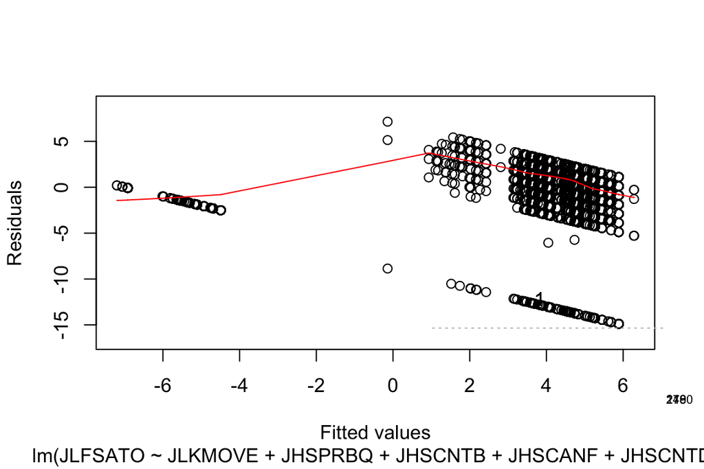

```r
library(ggplot2)
plot(Model2, 1, par(mfrow = c(2,2)))
```

In comparison, normal QQ-plot shows us if the residuals are normally distributed. The Theroeticial Quonatiles - plot (below) shows how residuals are lined well on the straight dashed line in the end, which means that they are rather but not quite normally distributed.

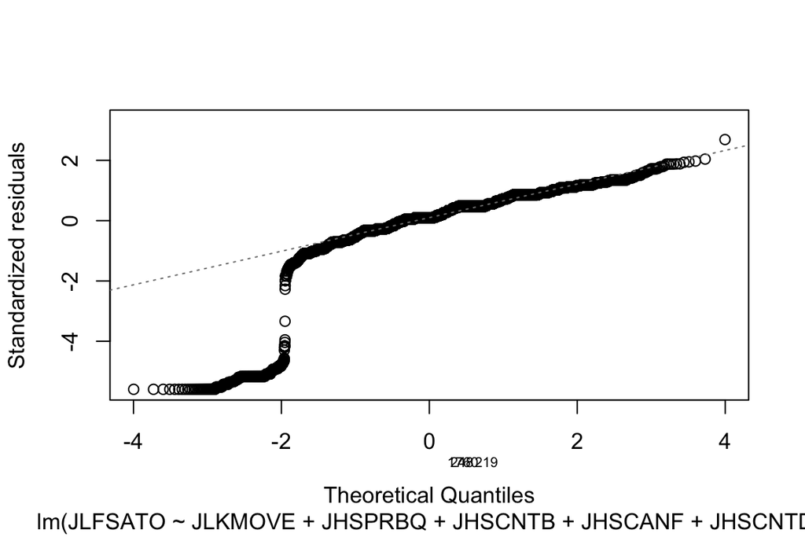

The last one, Residual vs leverage plot shows possible influential cases. According to the Levarage -plot, there is chance that there is influential case(s), one can see that almost all the cases are inside Cook’s distance lines, but since there is something in the upper and lower right corner, there also might be an influential case

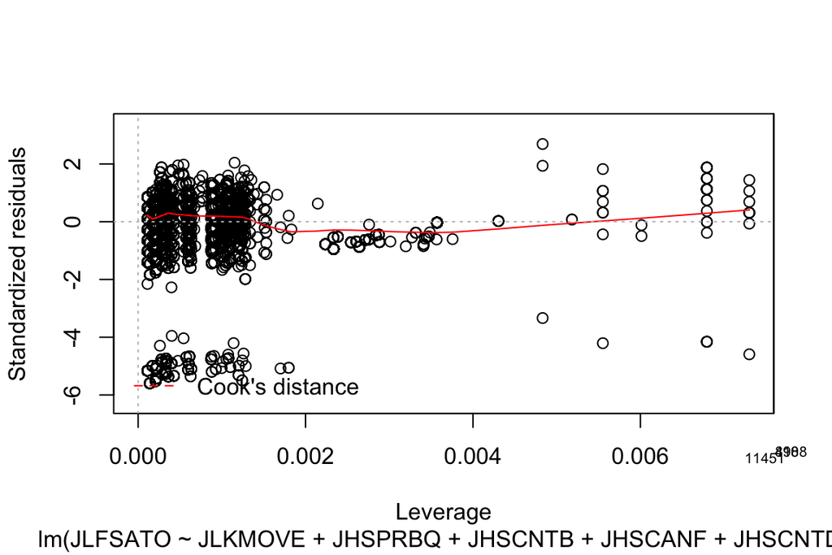

```r
plot(Model2, 5, par(mfrow = c(2,2)))
```

# CONCLUSIONS

The research question was about the correlation between the objective well-being factors and subjective well-being. Certainly, the model2 indicates that the objective well-being factors used in the model: the ability to move, quality of neighbourhood, ability to afford annual holiday and new clothes, and connects with friends and family, does not efficiently indicate subjective well-being, i.e. life satisfaction. However, when comparing the model1 and model2, the capability factors (capability to purchase annual holidays and new clothes) received significant correlation with life satisfaction than the actual outcome (purchased annual holidays and new clothes). Conclusively, perhaps the capability approach seem to have what really affects a person’s life satisfaction after all. For the end, there is a plot about the cababilities and one’s life satisfaction.

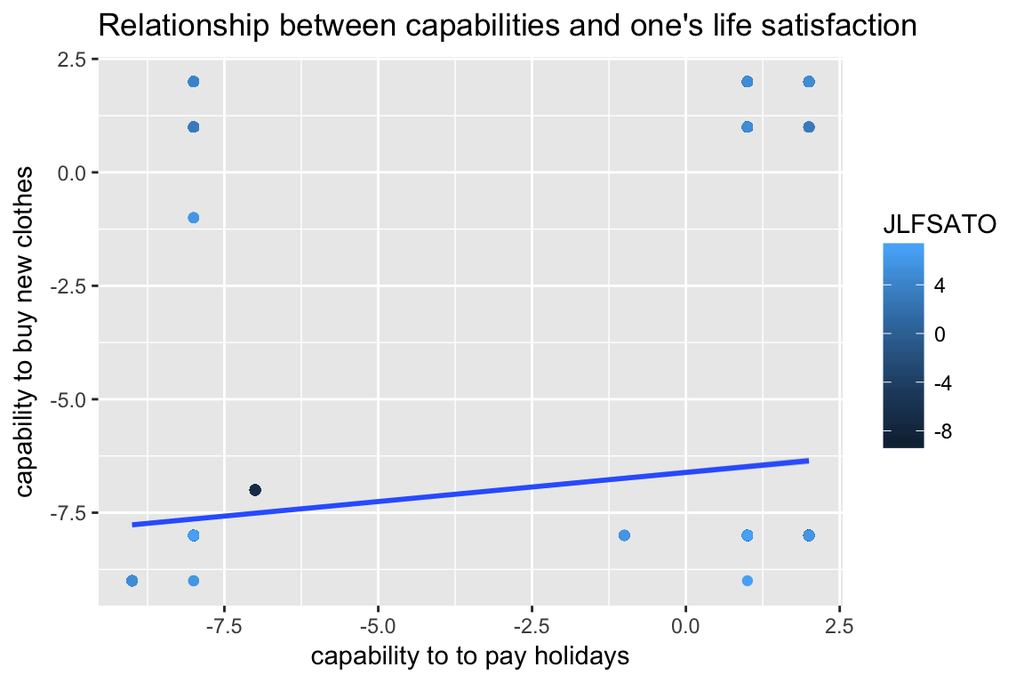

```r
p5 <- ggplot(BHPS2, aes(x = JHSCNTB, y = JHSCNTD, col = JLFSATO))
p6 <- p5 + geom_point()
p7 <- p6 + geom_smooth(method = "lm")
p8 <- p7 + ggtitle("Relationship between capabilities and one's life satisfaction") + xlab("capability to to pay holidays") + ylab("capability to buy new clothes")
p8
```

# REFERENCES

Armstrong, J. (2002). Illusion in Regression Analysis. Forthcoming, International Journal of Forecasting. Philadelphia. Available at: http://www.academia.edu/1105970/Illusions_in_Regression_Analysis. Last accessed 29.1.2017

Frost, J. (2013). Regression Analysis: How Do I Interpret R-squared and Assess the Goodness-of-Fit?. The minitab blog. Available at: http://blog.minitab.com/blog/adventures-in-statistics-2/regression-analysis-how-do-i-interpret-r-squared-and-assess-the-goodness-of-fit. Last accessed 29.1.2017.

Nuzzo, R. (2014). Statistical errors. P values, ‘the gold standard’ of statistical validity, are not as reliable as many scientist assume. Nature. 306. 150-152.